# Homework 2, Biostatistics

```r
library(gmodels)
library(epiR)
library(exact2x2)
library(fmsb)
library(psych)
library(BSDA)
library(MASS)
library(DiffXTables)
```

# Q1

```r
Q1_data=array(c(8,52,5,164,25,29,21,138,50,27,61,208),c(2,2,3),dimnames =list(c('Case','Control'),c('H','L'),c('35~44','45~54','55~64')))
Q1_data
```

```
## , , 35~44
##
##          H   L
## Case     8   5
## Control 52 164
##
## , , 45~54
##
##          H   L
## Case    25  21
## Control 29 138
##
## , , 55~64
##
##          H   L
## Case    50  61
## Control 27 208
```

## Q1 (a)

```r
mantelhaen.test(Q1_data, correct=F)
```

```
##
##  Mantel-Haenszel chi-squared test without continuity correction
##
## data:  Q1_data
## Mantel-Haenszel X-squared = 83.725, df = 1, p-value < 2.2e-16
## alternative hypothesis: true common odds ratio is not equal to 1
## 95 percent confidence interval:
##  3.959672 8.904458
## sample estimates:
## common odds ratio
##          5.937907
```

## Q1 (b)

compare 4 tables (group by age and crude) of odds ratio

```r
epi.2by2(Q1_data[,,1], method="case.control")
```

```
##              Outcome +    Outcome -      Total        Prevalence *        Odds
## Exposed +            8            5         13                61.5       1.600
## Exposed -           52          164        216                24.1       0.317
## Total               60          169        229                26.2       0.355
##
## Point estimates and 95% CIs:
## -------------------------------------------------------------------
## Odds ratio (W)                                 5.05 (1.58, 16.10)
## Attrib fraction (est) in the exposed (%)      80.01 (27.21, 95.08)
## Attrib fraction (est) in the population (%)   10.69 (1.03, 19.41)
## -------------------------------------------------------------------
## Yates corrected chi2 test that OR = 1: chi2(1) = 7.069 Pr>chi2 = 0.008
## Fisher exact test that OR = 1: Pr>chi2 = 0.006
##  Wald confidence limits
##  CI: confidence interval
##  * Outcomes per 100 population units
```

```r
epi.2by2(Q1_data[,,2], method="case.control")
```

```
##              Outcome +    Outcome -      Total        Prevalence *        Odds
## Exposed +           25           21         46                54.3        1.19
## Exposed -           29          138        167                17.4        0.21
## Total               54          159        213                25.4        0.34
##
## Point estimates and 95% CIs:
## -------------------------------------------------------------------
## Odds ratio (W)                                 5.67 (2.80, 11.46)
## Attrib fraction (est) in the exposed (%)      82.16 (61.99, 91.77)
## Attrib fraction (est) in the population (%)   38.12 (20.15, 52.05)
## -------------------------------------------------------------------
## Uncorrected chi2 test that OR = 1: chi2(1) = 26.065 Pr>chi2 = <0.001
## Fisher exact test that OR = 1: Pr>chi2 = <0.001
##  Wald confidence limits
##  CI: confidence interval
##  * Outcomes per 100 population units
```

```r
epi.2by2(Q1_data[,,3], method="case.control")
```

```
##              Outcome +    Outcome -      Total        Prevalence *        Odds
## Exposed +           50           61        111                45.0       0.820
## Exposed -           27          208        235                11.5       0.130
## Total               77          269        346                22.3       0.286
##
## Point estimates and 95% CIs:
## -------------------------------------------------------------------
## Odds ratio (W)                                 6.31 (3.65, 10.93)
## Attrib fraction (est) in the exposed (%)      84.06 (71.64, 91.21)
## Attrib fraction (est) in the population (%)   54.65 (38.12, 66.76)
## -------------------------------------------------------------------
## Uncorrected chi2 test that OR = 1: chi2(1) = 49.063 Pr>chi2 = <0.001
## Fisher exact test that OR = 1: Pr>chi2 = <0.001
##  Wald confidence limits
##  CI: confidence interval
##  * Outcomes per 100 population units
```

```r
epi.2by2(Q1_data[,,1]+Q1_data[,,2]+Q1_data[,,3], method="case.control")
```

```
##              Outcome +    Outcome -      Total        Prevalence *        Odds
## Exposed +           83           87        170                48.8       0.954
## Exposed -          108          510        618                17.5       0.212
## Total              191          597        788                24.2       0.320
##
## Point estimates and 95% CIs:
## -------------------------------------------------------------------
## Odds ratio (W)                                 4.51 (3.13, 6.49)
## Attrib fraction (est) in the exposed (%)      77.75 (67.43, 84.84)
## Attrib fraction (est) in the population (%)   33.81 (24.72, 41.80)
## -------------------------------------------------------------------
## Uncorrected chi2 test that OR = 1: chi2(1) = 71.346 Pr>chi2 = <0.001
## Fisher exact test that OR = 1: Pr>chi2 = <0.001
##  Wald confidence limits
##  CI: confidence interval
##  * Outcomes per 100 population units
```

# ——————————————————————————–

# Q2

```r
Q2_data = array(c(40,16,20,3),c(2,2),dimnames = list(c('A_success','A_failure'),c('B_success','B_success')))
Q2_data
```

```
##           B_success B_success
## A_success        40        20
## A_failure        16         3
```

matched data , McNemar’s (Chi-squared) test for antibiotics vs. gonorrhea and Exact McNemar’s test for antibiotics vs. gonorrhea

```r
mcnemar.test(Q2_data, correct=F)
```

```
##
##  McNemar's Chi-squared test
##
## data:  Q2_data
## McNemar's chi-squared = 0.44444, df = 1, p-value = 0.505
```

```r
mcnemar.exact(Q2_data)
```

```
##
##  Exact McNemar test (with central confidence intervals)
##
## data:  Q2_data
## b = 20, c = 16, p-value = 0.6177
## alternative hypothesis: true odds ratio is not equal to 1
## 95 percent confidence interval:
##  0.6154483 2.5796850
## sample estimates:
## odds ratio
##       1.25
```

whether approximate or exact p-value > 0.05,do not reject $H_0$(i.e antibiotics A and B in treating gonorrhea effectiveness is not different) ,

# ——————————————————————————–

# Q3

```r
Q3_data=array(c(35,21,13,249),c(2,2),dimnames = list(c('B_reviewer_+','B_reviewer_-'),c('A_reviewer_+','A_reviewer_-')))
Q3_data
```

```
##              A_reviewer_+ A_reviewer_-
## B_reviewer_+           35           13
## B_reviewer_-           21          249
```

Measure of agreement and its test

```r
Kappa.test(Q3_data)
```

```
## $Result
##
##  Estimate Cohen's kappa statistics and test the null hypothesis that
##  the extent of agreement is same as random (kappa=0)
##
## data:  Q3_data
## Z = 6.6765, p-value = 1.223e-11
## 95 percent confidence interval:
##  0.4856126 0.7336249
## sample estimates:
## [1] 0.6096187
##
##
## $Judgement
## [1] "Substantial agreement"
```

since p-value < 0.05 , reject $H_0$(i.e Kappa coefficient not equal to 0), and estimates is 0.6096187 , mean is Substantial agreement

# ——————————————————————————–

# Q4

## Q4(a)

$X_1,...,X_{10}$ ~ $Bin(20,p)$ where p is Pr($\theta\ \notin CI$) = 0.1 so Pr($X_1 \leq 3$) = $C^{20}_0 0.9^{20} + C^{20}_1 0.9^{19}0.1^1 + C^{20}_2 0.9^{18}0.1^2 + C^{20}_3 0.9^{17}0.1^3$

so each students have no more than 3 confidence intervals out of 20 is $(Pr(X_1 \leq 3))^{10}$

```r
probability_no_more_than_3 = pbinom(3,20,0.1)
probability_no_more_than_3^10
```

```
## [1] 0.240118
```

## Q4(b)

we can use goodness of fit test , $H_0 : X\sim Bin(20,0.1)$ vs.$H_1: not\ H_0$

and since the number of X=0 and X=1 is <5 so combin then and the number of X=4 and X>5 is <5 similar

```r
Q4_data=c(2+4,12,77,5+0)
chisq.test(Q4_data, p = c(dbinom(0,20,0.1)+dbinom(1,20,0.1),dbinom(2,20,0.1),dbinom(3,20,0.1),dbinom(4,20,0.1)+1-pbinom(4,20,0.1)))
```

```
##
##  Chi-squared test for given probabilities
##
## data:  Q4_data
## X-squared = 219.7, df = 3, p-value < 2.2e-16
```

p-value = 2.2e-16 < 0.05 , reject $H_0$

# ——————————————————————————–

# Q5

$H_0: median\ of\ case = median\ of\ control$ vs. $H_0: median\ of\ case \neq median\ of\ control$

nonparametric test , so use Wilcoxon rank-sum test

```r
Q5_data_1 = c(60, 25, 6, 8, 5, 10, 25, 15, 10)
Q5_data_2 = c(13, 20, 15, 7, 75, 120, 10, 100, 9, 25, 30)
# exact test
wilcox.test(Q5_data_1, Q5_data_2, paired=F, exact=T, alternative="two.side")
```

```
##
##  Wilcoxon rank sum test with continuity correction
##
## data:  Q5_data_1 and Q5_data_2
## W = 31.5, p-value = 0.1822
## alternative hypothesis: true location shift is not equal to 0
```

```r
# Normal approximation
wilcox.test(Q5_data_1, Q5_data_2, paired=F, exact=F, correct=F, alternative="two.side")
```

```
##
##  Wilcoxon rank sum test
##
## data:  Q5_data_1 and Q5_data_2
## W = 31.5, p-value = 0.17
## alternative hypothesis: true location shift is not equal to 0
```

whether exact or approximation p-value > 0.05 , so do not reject $H_0$ (i.e have equal median)

# ——————————————————————————–

# Q6

```r
Q6_data = matrix(c(243,16,83,36,60,32,31,31,39,12),c(2,5),dimnames = list(c('Number_children_with_caries','Number_children_with_caries_free_teeth'),c('Essex','Slough','Harwick','Burnham','Meresa')))
```

```r
Q6_data
```

```
##                                        Essex Slough Harwick Burnham Meresa
## Number_children_with_caries              243     83      60      31     39
## Number_children_with_caries_free_teeth    16     36      32      31     12
```

```r
two_cities_names = c()
p_value=c()
for (i in c(1:4)){
  for (j in c((i+1):5)){
  two_cities_names = c(two_cities_names,paste(colnames(Q6_data)[i],      colnames(Q6_data)[j], sep="_"))
  m = matrix( c(Q6_data[,i], Q6_data[,j]),c(2,2))
  p_value = c(p_value,chisq.test(m)$p.value)
  }
}
names(p_value) = two_cities_names
p_value
```

```
##    Essex_Slough   Essex_Harwick   Essex_Burnham    Essex_Meresa  Slough_Harwick
##    7.723903e-10    2.341697e-11    1.058299e-17    2.293943e-04    5.824846e-01
##  Slough_Burnham   Slough_Meresa Harwick_Burnham  Harwick_Meresa  Burnham_Meresa
##    1.432512e-02    4.799220e-01    8.606167e-02    2.272410e-01    7.159049e-03
```

# Bonferroni

```r
alpha = 0.05
adjust_p_palue = p.adjust(p_value, method="bonferroni")
sig = adjust_p_palue < alpha
print(adjust_p_palue[sig])
```

```
##  Essex_Slough Essex_Harwick Essex_Burnham  Essex_Meresa
##  7.723903e-09  2.341697e-10  1.058299e-16  2.293943e-03
```

# Sidak

```r
alpha = 0.05
adjust_p_palue = 1-(1-p_value)^(length(p_value))
sig = adjust_p_palue < alpha
print(adjust_p_palue[sig])
```

```
##  Essex_Slough Essex_Harwick Essex_Burnham  Essex_Meresa
##  7.723903e-09  2.341694e-10  0.000000e+00  2.291577e-03
```

# Holm

```r
alpha = 0.05
adjust_p_palue = p.adjust(p_value, method="holm")
sig = adjust_p_palue < alpha
print(adjust_p_palue[sig])
```

```
##   Essex_Slough  Essex_Harwick  Essex_Burnham   Essex_Meresa Burnham_Meresa
##   6.179122e-09   2.107527e-10   1.058299e-16   1.605760e-03   4.295429e-02
```

# Hochberg

```r
alpha = 0.05
adjust_p_palue = p.adjust(p_value, method="hochberg")
sig = adjust_p_palue < alpha
print(adjust_p_palue[sig])
```

```
##   Essex_Slough  Essex_Harwick  Essex_Burnham   Essex_Meresa Burnham_Meresa
##   6.179122e-09   2.107527e-10   1.058299e-16   1.605760e-03   4.295429e-02
```

# Benjamini-Hochberg

```r
alpha = 0.05
adjust_p_palue = p.adjust(p_value, method="BH")
sig = adjust_p_palue < alpha
print(adjust_p_palue[sig])
```

```
##   Essex_Slough  Essex_Harwick  Essex_Burnham   Essex_Meresa Slough_Burnham
##   2.574634e-09   1.170848e-10   1.058299e-16   5.734858e-04   2.387521e-02
## Burnham_Meresa
##   1.431810e-02
```

We then plot ordered unadjusted p-values vs. indices compared to various multiple comparison procedures.

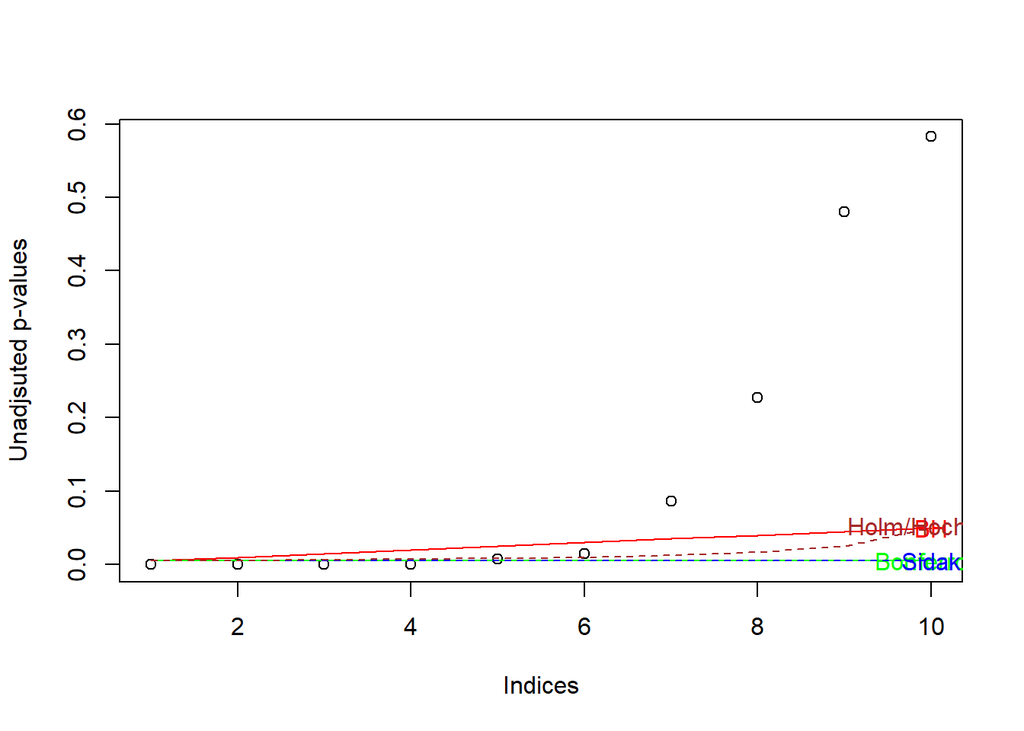

```r
len = length(p_value)
plot(c(1:len),sort(p_value), xlab="Indices", ylab="Unadjsuted p-values")
lines(1:len, (1:len)*alpha/len, col="red", lty=1)
text(len, len*alpha/len, labels="BH", col="red")
lines(1:len, rep(alpha/len, len), col="green", lty=1)
text(len, alpha/len, labels="Bonferroni", col="green")
lines(1:len, rep(1-(1-alpha)^{1/len}, len), col="blue", lty=2)
text(len, 1-(1-alpha)^{1/len}, labels="Sidak", col="blue")
lines(1:len, alpha/(len:(len-(len-1))), col="brown", lty=2)
text(len, alpha/(len-(len-1)), labels="Holm/Hochberg", col="brown")
```